# LAH FinalProject R

I work in a microbiome lab, so a lot of what we do involves high throughput 16S genomic sequencing. Currently we collaborate with a bioinformaticist to analyze this data, but I would like to be able to do some of the analysis myself. My research specifically involves uncovering how differential abundance of species in the Lachnospiraceae family in the infant gut microbiome are related to the onset of food allergy. One thing I am curious about is if / to what extent these specific species are affected by antibiotic use. To begin to ask this question, I have obtained a dataset from DIABIMMUNE, an online database of microbial sequencing from several demographic cohorts. I will be using 16S sequencing data from their antibiotics cohort (NCBI BioProject ID PRJNA290381). The goal of this section of my project is to clean and combine the data obtained online, and pull out and visualize the information on the bacterial family that pertains to my research.  
Source data: https://pubs.broadinstitute.org/diabimmune/antibiotics-cohort

## Part I: Cleaning and Joining Data

The data exists in two csv files: one contains the metagenomic data, the other with the antibiotics treatment information. I need to upload these, change from a “wide” table into a “long” table, and merge the two by infant ID number. Each infant has several outputs for each taxa due to the method of sequencing, for example “periodic relative abundance”, “early strong relative abundance”, etc. For this project the specifics of the sequencing aren’t particularly relevant, so I chose to average each of these outputs for each taxa for each individual. This way we only have one output value, rather than 3-5. I also chose to exclude any viruses from the dataset, because these arent relevant to the project.

```r
library(tidyverse)
#don't forget to set working directory
rel_abundance <- read_csv("LAH_all.relative_abundance.noabx.csv")
abx_groups <- read_csv("abx_metadata_brief.csv")
clean_rel_abundance <- rel_abundance %>% gather(ID, Abundance,
                                                E000823_1.8.periodic.relative_abundance:
                                                  E035134_34.8.periodic.relative_abundance)

#make a new column that just has the individual's ID number, not the periodic/early sequencing info.
clean_rel_abundance <- clean_rel_abundance %>% mutate(ID_number = substr(ID, 1, 7))

#calculate an average abundance for each input for a single taxa AND single individual.
clean_rel_abundance_avg <- aggregate(select(clean_rel_abundance, "Abundance"),
                                  by = list(clean_rel_abundance$Taxa, clean_rel_abundance$ID_number), FUN = mean)
colnames(clean_rel_abundance_avg) <- c("Taxa", "ID_number", "Avg_Abundance")

#rename this as its own tibble. We also don't care about viruses so remove those
Relative_abundance <- clean_rel_abundance_avg %>% filter(grepl("Viruses", Taxa) == FALSE)
Rel_abundance_abx <- merge(Relative_abundance, abx_groups, by = 'ID_number')
```

## Part II: Isolating and Visualizing

We now have a clean, useful tibble, but it still has over 200,000 observations. It will be very difficult to see anything useful from this huge dataset. I know that the data includes a summary abundance value for each taxonomic level (family, order, phylum, etc.). First I want to pull out only the Order level summaries, to look at a wide variety of bacterial taxa. To do this I will filter the data for Taxa values that do include the order designation, but not family (and by proxy any lower groups). Then in a separate tibble, I will pull out only the data corresponding to my family of interest, Lachnospiraceae. Note that because there were a few high values and many very small values, I took the square root of the average abundance output for better visualization.

```r
#pull out summary abundances at the order level, we don't want family- or genus-level details.
Order_abundance <- Relative_abundance %>% filter(grepl('f__', Taxa) == FALSE, grepl('o__', Taxa) == TRUE)
Order_abundance <-merge(Order_abundance, abx_groups, by = 'ID_number')
Order_abundance <- Order_abundance %>% mutate(Sqrt.Abundance = sqrt(Avg_Abundance))

#pull out only the family Lachnospiraceae
Lachno_abundance <- Relative_abundance %>% filter(grepl('Lachnospiraceae', Taxa) == TRUE)

#make shorter taxa names for prettier graph. The first 80 characters are the higher order Taxa, so remove those.
#also filter out the unnamed species because we don't care about those at this point
Lachno_abundance <- Lachno_abundance %>% mutate(Taxa_short = substr(Taxa, 80, nchar(Taxa))) %>%
  filter(grepl("noname", Taxa_short) == FALSE)
Lachno_abundance <- merge(Lachno_abundance, abx_groups, by = 'ID_number')
Lachno_abundance <- Lachno_abundance %>% mutate(Sqrt.Abundance = sqrt(Avg_Abundance))
```

I used ggplot to create heatmaps of these two datasets. One thing I had to learn was that even if I had my data arranged by antibiotic treatment group, once it entered ggplot it was rearranged. The facet_grid function allowed me to arrange the data in the graph by another variable not included in the graph and splice it together nicely. In future projects I’d like to do more to clean up the Taxa labels, but I was having difficulty pulling out substrings of different lengths with different start/end points. I’d also like to use a substring replace to get rid of the taxonomic level markers (k, c, o, etc.) and the underscores between levels. Unfortunately, as can be seen from the plots below it does not seem that my code pulls out many significant differences between the antibiotic-treated and untreated groups. I was pleased to see a high abundance of Clostridiales (relevant to my research) and Bfidobacteria (generally considered to be an important taxa for infants). I was very surprised that there was minimal effect of antibiotic treatment. I was also surprised that Anaerostipes caccae, my species of interest, was not at all abundant while Anaerostipes hadrus (which many consider to be A. caccae’s adult counterpart) had some presence in this infant cohort.

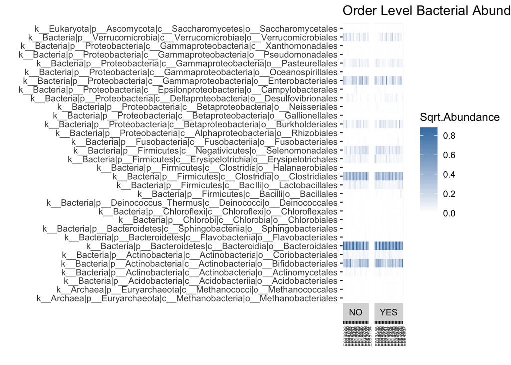

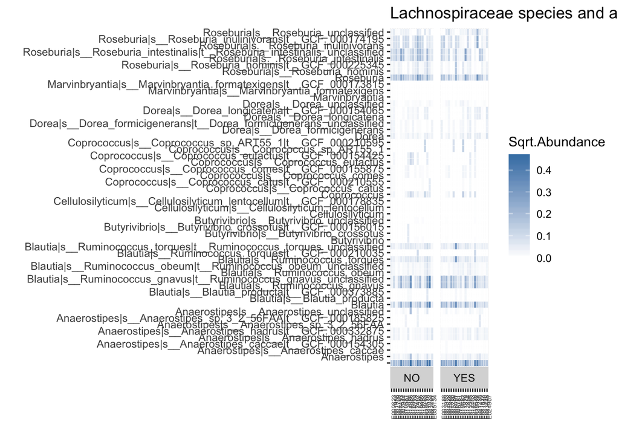